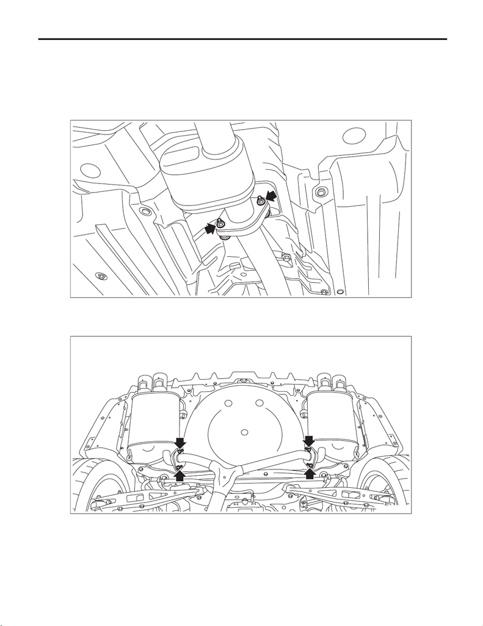

EX(w/o STI)-50

Rear Exhaust Pipe

EXHAUST

4. Rear Exhaust Pipe

A: REMOVAL

CAUTION:

Vehicle components are extremely hot after driving. Be wary of receiving burns from heated parts.

1) Lift up the vehicle.

2) Remove the bolts, springs, and nuts which secure the center exhaust pipe (rear) to the rear exhaust pipe.

3) Remove the bolts and self-locking nuts securing the mufflers to the rear exhaust pipes.

CAUTION:

Be careful not to drop the rear exhaust pipe.

4) Apply a coat of spray type lubricant to the mating area of cushion rubber.

EX-02971

EX-03128

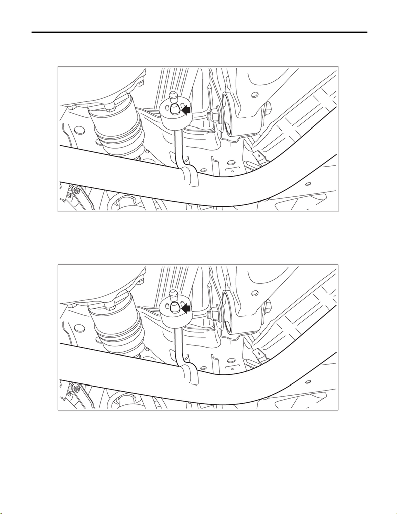

EX(w/o STI)-51

Rear Exhaust Pipe

EXHAUST

5) Remove the rear exhaust pipe from the cushion rubber.

CAUTION:

Be careful not to let the muffler contact the rear bumper.

B: INSTALLATION

1) Apply a coat of spray type lubricant to the mating area of cushion rubber.

2) Install the rear exhaust pipe to cushion rubber.

NOTE:

After assembling, degrease the lubricant which was applied to the cushion rubber while removing/installing.

EX-03004

EX-03004

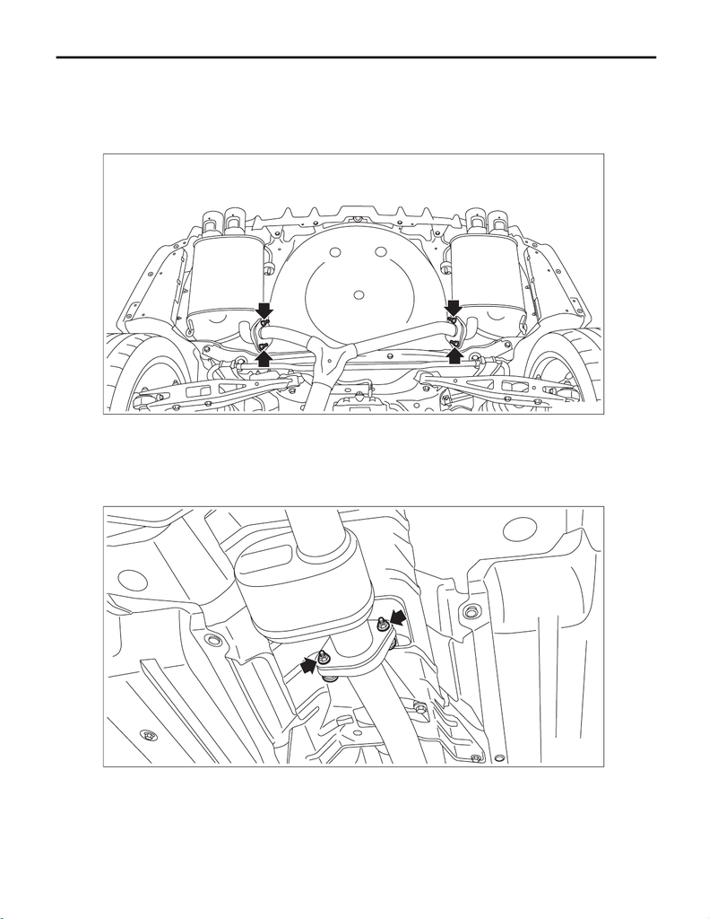

EX(w/o STI)-52

Rear Exhaust Pipe

EXHAUST

3) Install the bolts and self-locking nuts which secure the muffler to the rear exhaust pipe.

NOTE:

Use a new gasket and self-locking nut.

Tightening torque:

48 N·m (4.9 kgf-m, 35.4 ft-lb)

4) Install the bolts, springs, and nuts which secure the center exhaust pipe (rear) to the rear exhaust pipe.

NOTE:

Use a new gasket.

Tightening torque:

18 N·m (1.8 kgf-m, 13.3 ft-lb)

5) Lower the vehicle.

C: INSPECTION

1) Check the connections and welded parts for exhaust leaks.

2) Make sure there are no holes or rusting.

3) Check the cushion rubber for wear or crack.

EX-03128

EX-02971